# Why degree

When confronted with the question “How would this degree help fulfill your aspirations?”, I thought nothing talks louder than data. So I collected some data and did this analysis.

# Data Collection

- I searched for jobs named “data scientist”, and checked out the most relevant 120 results.
- Then I selected jobs with specific requirements about degrees.
- And I also selected jobs with different job level to see the trend.

# Overview of data

```
##                      Company Minimum.Requirement      Industry Location
## 1                      Intel                M.S.            CS  America
## 2           Texas Instrument                M.S. Manufacturing  America
## 3         Protector & Gamble                B.S.        Retail  America
## 4 The Advisory Board Company                B.S.        Health  America
## 5                    Sandisk                M.S.            CS  America
## 6                CyberCoders                M.S.            CS  America
##   Job.Level Fortune500
## 1    Junior          1
## 2    Junior          1
## 3    Junior          1
## 4    Junior          0
## 5    Junior          1
## 6    Junior          0
```

Then we check out how many of them requires a Master degree.

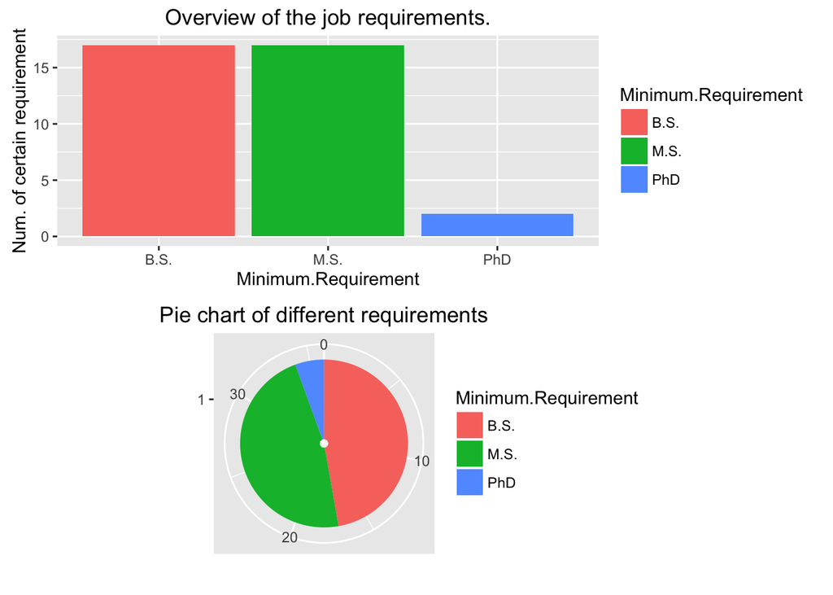

Here we can see that half of the jobs do not require a master degree. Then why should I need one?

# Why should I need a master degree

## A master degree is a license to senior jobs

Unlike the previous analysis, more senior jobs require a master degree

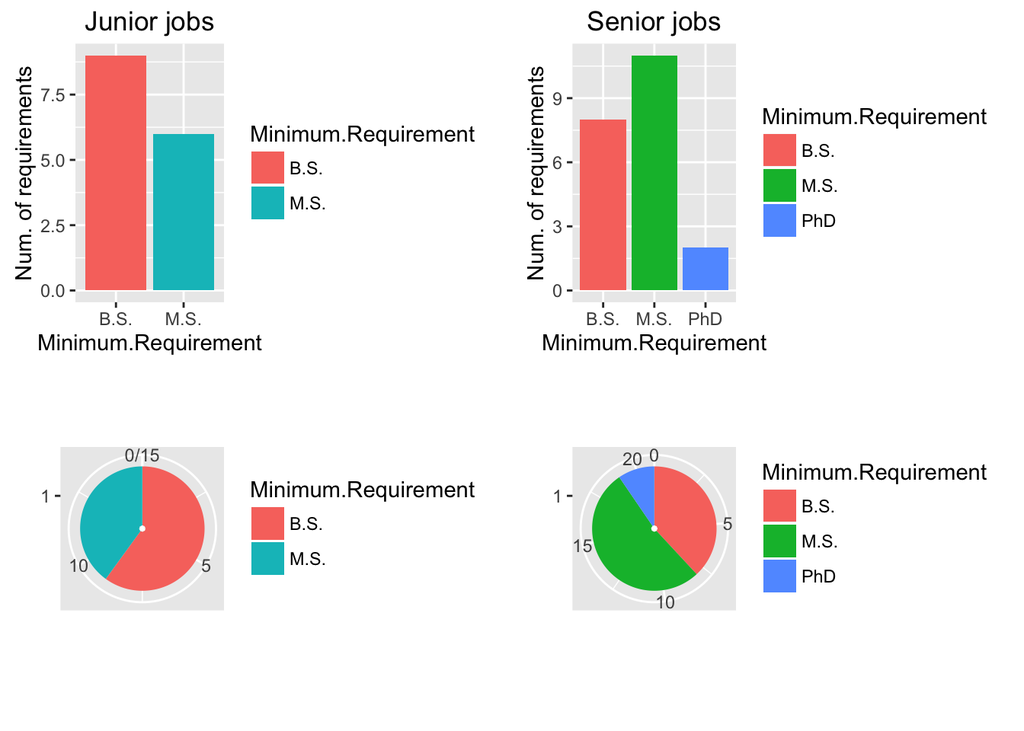

The total number of jobs from different job level are different. So it’s better to compare them via pie chart.  
And we can observe that a larger part of senior jobs require a master degree.

## A master degree is a license to Fortune 500 companies

Things are more obvious when talking about jobs in a Fortune 500 company.

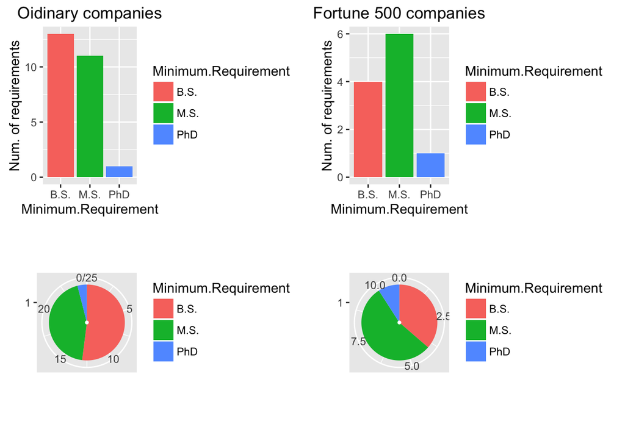

When we focus on the pie chart, we can see a larger part of jobs offered by a Fortune 500 company requires a master degree.

## Sum up

In a word, a master degree can give me more opportunities as being an outstaning data scientist. Espeically a master degree of business analytics offered by MIT.